# Residuals Diagnostics

Econometrics - ECON 426

## Importing data into R

For this lecture, we will be using the `food` data from PoE data set that can be found at http://www.principlesofeconometrics.com/poe5/poe5data.html.

```r
food <- read.csv("data/food.csv")
```

Estimate the linear model

```r
mod1 <- lm(food_exp ~ income, data = food)
```

## Fitted and residual values

## Fitted and residual values

- After estimating a model, the fitted values and the residuals can be accessed via the `$`.
- Model object contains several components.
- Components within an object can be accessed by appending a dollar sign, `$`, and the name of the component.
- The following code stores fitted values, i.e. \(\hat{y}\), and the residues, \(e\).

```r
fitted <- mod1$fitted.values
resid <- mod1$residuals
```

## Actual vs Fitted Plot

In this plot, the closer each point is to the solid line, the closer \(\hat{y}\) is to \(y\).

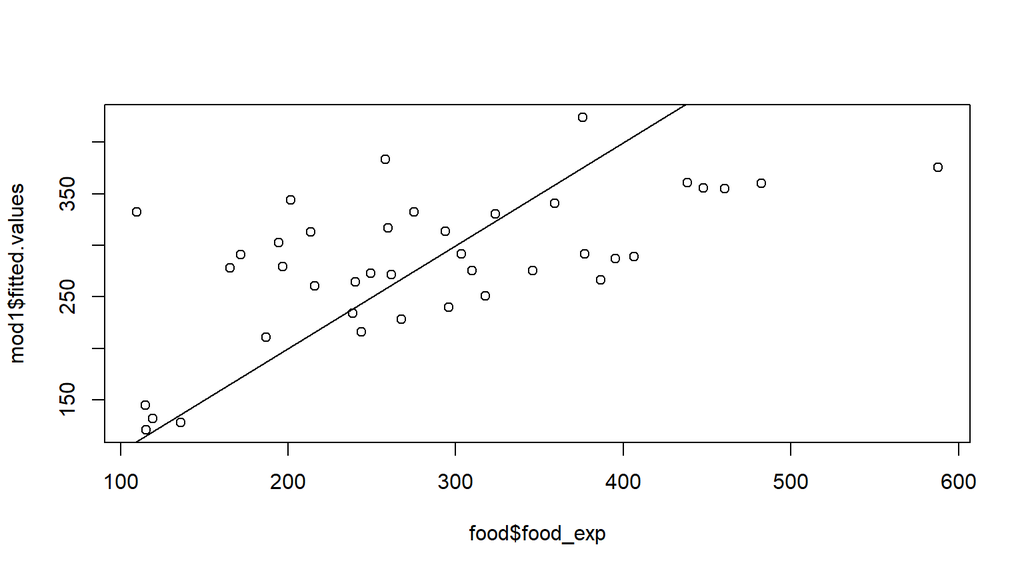

```r
plot(x=food$food_exp,y=mod1$fitted.values)
abline(0,1)
```

## “Perfect” fitted and residual values

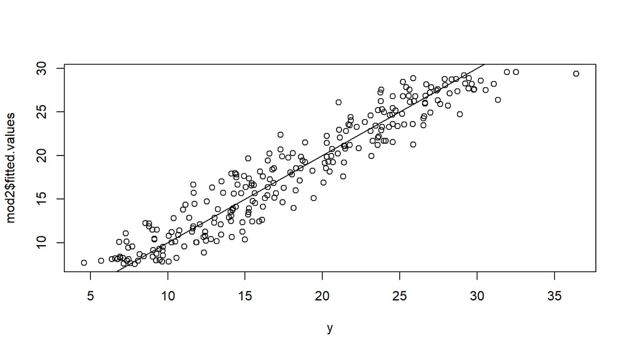

## Residuals vs. Fit Plot

## One of the best diagnostic plots

- One of the best diagnostic plots is the residuals vs. fit plot.
- You can draw the residuals vs. fit plot with the `plot()` function.

-But a much more attractive plot can be obtained using ggplot2

## Packages

- The following code chunk test weather the tidyverse has been installed, installs the package if needed, and then loads the package.

```r
if (!require("tidyverse")) install.packages("tidyverse")
  suppressMessages(library(tidyverse))
```

- `install.packages()` command installs the package
- `library()` command loads the package. For now, you can copy this code and paste this code to use it in your own analysis.

## `plot.fitted()`

```r
plot.fitted <- function(lmod) {
  df = lmod$model
  title = paste("Residuals vs. Fits (Dependent Variable: ",
                names(df)[1],
                ")",
                sep = "")
  pr <- df %>% ggplot(aes(x = fitted(lmod), y = resid(lmod))) +
    geom_ribbon(aes(ymin = -sigma(lmod), ymax = sigma(lmod)),
                fill = "gray",
                alpha = .5) +
    geom_ribbon(aes(ymin = -sigma(lmod)*2, ymax = sigma(lmod)*2),
                fill = "lightgray",
                alpha = .5) +
    geom_point() +
    theme_classic() +
    ggtitle(title) +
    ylab("Residules") +
    xlab("Fitted") +
    geom_hline(yintercept = 0,
               linetype = "solid",
               color = "black")
  return(pr)
}
```

## Residuals vs. Fit Plot

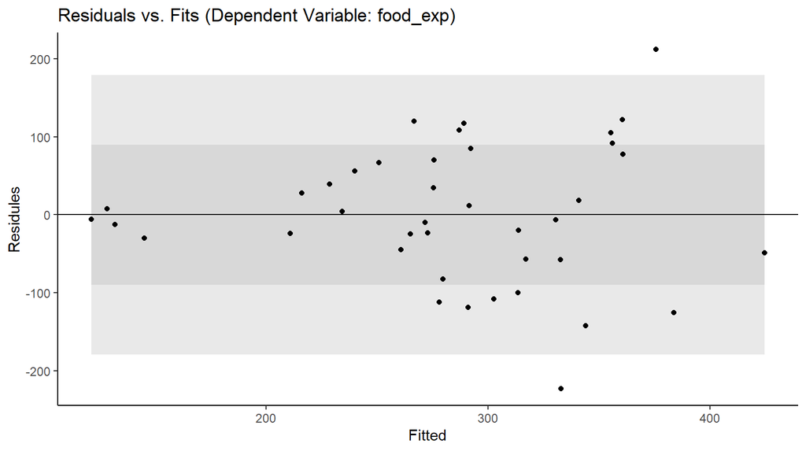

```r
plot.fitted(mod1)
```

## “Perfect” Residuals vs. Fit Plot

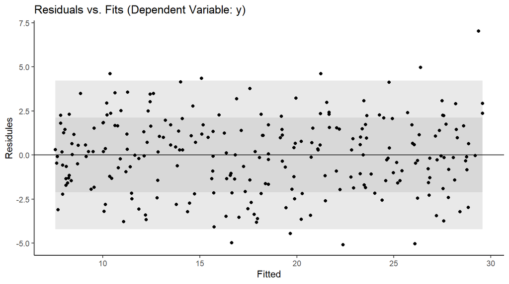

```r
plot.fitted(mod2)
```

## Normality of residuals

## Normal Plot

- The residuals from the regression model should have an approximately normal distribution.
- Linear regression is rather robust to violations of this assumption, so it is sufficient to examine a histogram of the residuals.
- I have written a function for you `plot.normal()` that draws a histogram of the residuals

## `plot.normal()`

```r
plot.normal <- function(lmod) {
  res <- resid(lmod)
  hist(res, probability = T)
  curve(
    dnorm(x, mean = mean(res), sd = (sd(res))),
    col = "darkblue",
    lwd = 2,
    add = TRUE,
    yaxt = "n"
  )
}
```

## Residuals Histogram

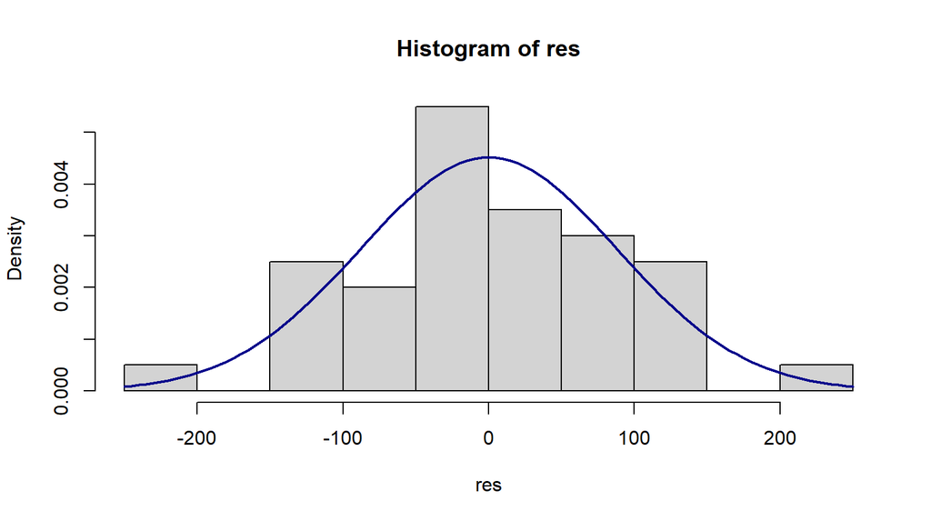

```r
plot.normal(mod1)
```

## “Perfect” Residuals Histogram

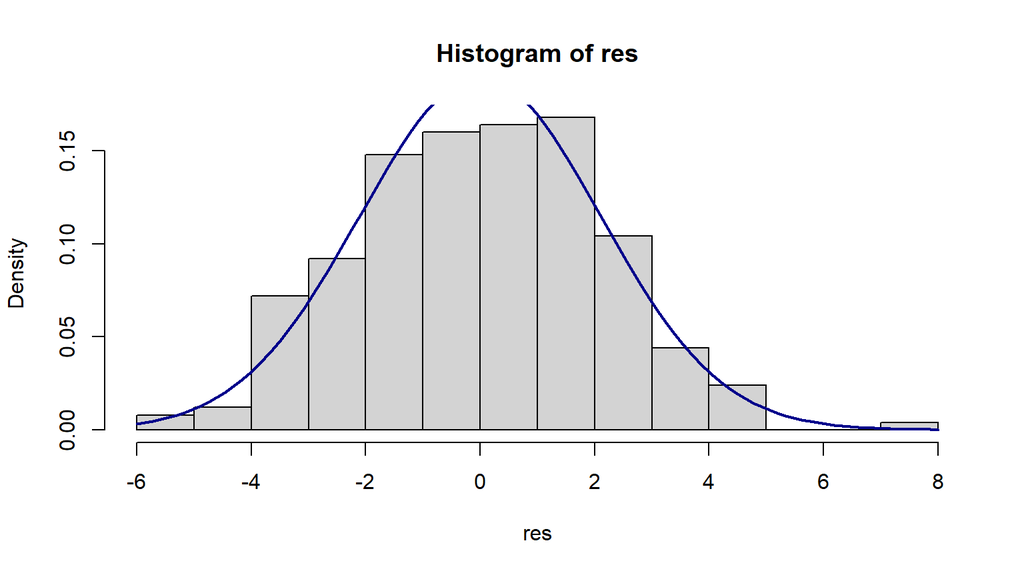

```r
plot.normal(mod2)
```

## You did it!